# Latihan 3 MPDW

Wiska Radhia Firdaus - G1401231017

2025-09-16

# Library

```r
library(dLagM)
library(dynlm)
library(MLmetrics)
library(lmtest)
library(car)
library(readr)
library(dplyr)
```

# Import Data

```r
df <- read.csv("D:\\File\\Data Science\\Semester 5\\MPDW\\Praktikum\\Minggu 4\\NewDelhi_Air_quality.csv")
df
```

```
##     X  AQI       CO      datetime        no2       o3      pm10     pm25
## 1   0 30.2 198.6027 2022-10-21:18 0.04685717 55.78995 10.486722 5.637410
## 2   1 28.2 197.6013 2022-10-21:19 0.04645554 54.93164 10.719325 4.618169
## 3   2 26.6 198.6027 2022-10-21:20 0.04685717 54.64554 11.155578 3.520902
## 4   3 25.0 201.9405 2022-10-21:21 0.04819594 55.07469 11.116206 2.225919
## 5   4 26.0 205.2784 2022-10-21:22 0.04886533 55.78995 10.405250 1.979471
## 6   5 26.0 208.6163 2022-10-21:23 0.05020411 56.50520  9.402518 1.792677
## 7   6 26.0 208.6163 2022-10-22:00 0.05020411 55.78995  8.482822 1.752237
## 8   7 24.0 205.2784 2022-10-22:01 0.05020411 52.92892  7.586667 1.858459
## 9   8 23.0 200.2716 2022-10-22:02 0.04685717 50.06790  7.636587 2.208076
## 10  9 24.0 196.9338 2022-10-22:03 0.04417961 51.49841  8.487648 2.476681
## 11 10 25.0 198.6027 2022-10-22:04 0.04284084 53.64418  9.357371 2.585729
## 12 11 26.0 200.2716 2022-10-22:05 0.04049798 55.78995 10.338728 2.390081
## 13 12 27.0 203.6095 2022-10-22:06 0.04016329 59.36623 10.523314 2.086022
## 14 13 29.0 205.2784 2022-10-22:07 0.03882451 62.22725 10.635970 1.937047
```

[output cut: 131 more lines]

```r
str(df)
```

```
## 'data.frame':    72 obs. of  12 variables:
##  $ X              : int  0 1 2 3 4 5 6 7 8 9 ...
##  $ AQI            : num  30.2 28.2 26.6 25 26 26 26 24 23 24 ...
##  $ CO             : num  199 198 199 202 205 ...
##  $ datetime       : chr  "2022-10-21:18" "2022-10-21:19" "2022-10-21:20" "2022-10-21:21" ...
##  $ no2            : num  0.0469 0.0465 0.0469 0.0482 0.0489 ...
##  $ o3             : num  55.8 54.9 54.6 55.1 55.8 ...
##  $ pm10           : num  10.5 10.7 11.2 11.1 10.4 ...
##  $ pm25           : num  5.64 4.62 3.52 2.23 1.98 ...
##  $ so2            : num  0.387 0.41 0.402 0.376 0.339 ...
##  $ timestamp_local: chr  "2022-10-21T23:00:00" "2022-10-22T00:00:00" "2022-10-22T01:00:00" "2022-10-22T02:00:00" ...
##  $ timestamp_utc  : chr  "2022-10-21T18:00:00" "2022-10-21T19:00:00" "2022-10-21T20:00:00" "2022-10-21T21:00:00" ...
##  $ ts             : int  1666375200 1666378800 1666382400 1666386000 1666389600 1666393200 1666396800 1666400400 1666404000 1666407600 ...
```

```r
data <- df %>% select(-c('X', 'datetime', 'no2', 'o3', 'pm10', 'pm25', 'so2', 'timestamp_local', 'timestamp_utc', 'ts'))
head(data)
```

```
##    AQI       CO
## 1 30.2 198.6027
## 2 28.2 197.6013
## 3 26.6 198.6027
## 4 25.0 201.9405
## 5 26.0 205.2784
## 6 26.0 208.6163
```

Variabel yang digunakan adalah AQI sebagai variabel dependen dan CO sebagai variabel independen.

# Pembagian Data

```r
train<-data[1:54,]
test<-data[55:72,]
```

Pembagian data menggunakan rasio 3:1, dimana train berjumlah 54 amatan dan test berjumlah 18 amatan.

```r
train.ts<-ts(train)
test.ts<-ts(test)
data.ts<-ts(data)
```

# Model Koyck

## Pemodelan

```r
model.koyck <- koyckDlm(x = train$CO, y = train$AQI)
summary(model.koyck)
```

```
##
## Call:
## "Y ~ (Intercept) + Y.1 + X.t"
##
## Residuals:
##      Min       1Q   Median       3Q      Max
## -2.01328 -0.49464  0.03244  0.58868  2.27048
##
## Coefficients:
##             Estimate Std. Error t value Pr(>|t|)
## (Intercept)  5.28397   10.04682   0.526    0.601
## Y.1          0.90541    0.08492  10.662 1.78e-14 ***
## X.t         -0.01370    0.05734  -0.239    0.812
## ---
## Signif. codes:  0 '***' 0.001 '**' 0.01 '*' 0.05 '.' 0.1 ' ' 1
##
## Residual standard error: 0.9469 on 50 degrees of freedom
## Multiple R-Squared: 0.8177,  Adjusted R-squared: 0.8104
## Wald test: 112.7 on 2 and 50 DF,  p-value: < 2.2e-16
##
## Diagnostic tests:
## NULL
##
##                             alpha        beta       phi
## Geometric coefficients:  55.86447 -0.01369588 0.9054144
```

```r
AIC(model.koyck)
```

```
## [1] 149.5384
```

```r
BIC(model.koyck)
```

```
## [1] 157.4196
```

Dari hasil tersebut, didapat bahwa peubah $AQI_{-1}$ memiliki nilai $p-value<0.05$. Hal ini menunjukkan bahwa peubah $AQI_{-1}$ berpengaruh signifikan terhadap $AQI$. Model ini juga memiliki nilai adjusted R-sq sebesar 0.8104. Adapun model keseluruhannya adalah sebagai berikut.

$$\hat{AQI_t}=5.28397-0.01370CO_t+0.90541AQI_{t-1}$$

## Peramalan dan Akurasi

Berikut adalah hasil peramalan $AQI$ untuk 18 periode kedepan menggunakan model koyck.

```r
fore.koyck <- forecast(model = model.koyck, x=test$CO, h=18)
fore.koyck
```

```
## $forecasts
##  [1] 27.01012 27.01929 27.02759 27.03510 27.06476 27.13733 27.20304 27.28539
##  [9] 27.35995 27.42745 27.48858 27.54392 27.59402 27.61653 27.61406 27.58896
## [17] 27.54337 27.50210
##
## $call
## forecast.koyckDlm(model = model.koyck, x = test$CO, h = 18)
##
## attr(,"class")
## [1] "forecast.koyckDlm" "dLagM"
```

```r
mape.koyck <- MAPE(fore.koyck$forecasts, test$AQI)
mape.koyck
```

```
## [1] 0.2147603
```

```r
GoF(model.koyck)
```

```
##              n     MAE         MPE       MAPE      sMAPE     MASE       MSE
## model.koyck 53 0.69404 -0.00111704 0.02563878 0.02556194 1.087051 0.8459109
##                  MRAE    GMRAE
## model.koyck 799356386 12045.11
```

# Regression with Distributed Lag

```r
model.dlm <- dlm(x = train$CO,y = train$AQI , q = 1)
summary(model.dlm)
```

```
##
## Call:
## lm(formula = model.formula, data = design)
##
## Residuals:
##     Min      1Q  Median      3Q     Max
## -4.2868 -0.7687  0.3511  0.9769  3.5935
##
## Coefficients:
##              Estimate Std. Error t value Pr(>|t|)
## (Intercept) -48.44635   13.10221  -3.698 0.000541 ***
## x.t           0.44673    0.13254   3.370 0.001454 **
## x.1          -0.07176    0.13182  -0.544 0.588584
## ---
## Signif. codes:  0 '***' 0.001 '**' 0.01 '*' 0.05 '.' 0.1 ' ' 1
##
## Residual standard error: 1.68 on 50 degrees of freedom
## Multiple R-squared:  0.4265, Adjusted R-squared:  0.4036
## F-statistic: 18.59 on 2 and 50 DF,  p-value: 9.184e-07
##
## AIC and BIC values for the model:
##        AIC      BIC
## 1 210.2894 218.1706
```

```r
AIC(model.dlm)
```

```
## [1] 210.2894
```

```r
BIC(model.dlm)
```

```
## [1] 218.1706
```

$$\hat{AQI_t}=-48.44635+0.44673CO_t-0.07176CO_{t-1}$$

## Peramalan dan Akurasi

Berikut merupakan hasil peramalan $AQI$ untuk 18 periode kedepan.

```r
fore.dlm <- forecast(model = model.dlm, x=test$CO, h=18)
fore.dlm
```

```
## $forecasts
##  [1] 25.90334 26.02311 26.02311 26.02311 25.27755 23.90620 24.14573 23.40017
##  [9] 23.51993 23.51993 23.51993 23.51993 23.51993 24.26549 24.89129 25.51708
## [17] 26.14288 26.02311
##
## $call
## forecast.dlm(model = model.dlm, x = test$CO, h = 18)
##
## attr(,"class")
## [1] "forecast.dlm" "dLagM"
```

```r
mape.dlm <- MAPE(fore.dlm$forecasts, test$AQI)
mape.dlm
```

```
## [1] 0.1097238
```

```r
GoF(model.dlm)
```

```
##            n      MAE          MPE       MAPE      sMAPE     MASE      MSE
## model.dlm 53 1.213569 -0.003556697 0.04487017 0.04426057 1.900771 2.661538
##                 MRAE    GMRAE
## model.dlm 5014642890 29598.72
```

## *Lag* Optimum

```r
finiteDLMauto(formula = AQI ~ CO,
              data = data.frame(train), q.min = 1, q.max = 30,
              model.type = "dlm", error.type = "AIC", trace = TRUE)
```

```
##    q - k    MASE       AIC       BIC        GMRAE    MBRAE R.Adj.Sq
## 26    26 0.00000      -Inf      -Inf      0.00001  0.24074      NaN
## 27    27 0.00000      -Inf      -Inf      0.00001  0.25000      NaN
## 28    28 0.00000      -Inf      -Inf      0.00001  0.24000      NaN
## 29    29 0.00000      -Inf      -Inf      0.00001  0.25000      NaN
## 30    30 0.00000      -Inf      -Inf      0.00001  0.23913      NaN
## 25    25 0.11847  -3.66140  34.62288   2176.65832  0.46361  0.98215
## 24    24 0.41523  67.90703 105.73936   6400.71180  0.46505  0.88138
## 23    23 0.47464  78.91191 116.19557   7819.00992  0.49595  0.87363
## 22    22 0.59782  83.87747 120.52087  19196.28729  0.52401  0.87797
## 21    21 0.65304  87.40712 123.32330  23980.06935  0.49745  0.88126
## 20    20 0.69866  90.61046 125.71675  37648.84242  0.51799  0.88196
## 19    19 0.76707  94.44604 128.66370  55985.63974  0.46295  0.87812
## 18    18 0.81424  96.15024 129.40414  77586.83559  0.48956  0.87998
## 17    17 0.82373  97.47949 129.69785  61949.82773  0.49559  0.88165
```

[output cut: 47 more lines]

Berdasarkan output tersebut, lag optimum didapatkan ketika lag = 25. Selanjutnya dilakukan pemodelan untuk lag = 25.

```r
model.dlm2 <- dlm(x = train$CO,y = train$AQI , q = 25)
summary(model.dlm2)
```

```
##
## Call:
## lm(formula = model.formula, data = design)
##
## Residuals:
##         1         2         3         4         5         6         7         8
## -0.119056 -0.034553  0.174393 -0.057047 -0.074125 -0.038148  0.023781  0.031839
##         9        10        11        12        13        14        15        16
##  0.043614  0.035445 -0.090929 -0.049438  0.095647  0.142360 -0.029236 -0.113972
##        17        18        19        20        21        22        23        24
## -0.079187  0.010590  0.081370  0.040204 -0.044872 -0.016850  0.136423  0.062949
##        25        26        27        28        29
## -0.092643 -0.200633  0.066986  0.097378 -0.002292
##
## Coefficients:
##               Estimate Std. Error t value Pr(>|t|)
## (Intercept)  1.862e+03  3.135e+02   5.939   0.0272 *
## x.t         -7.470e-01  2.580e-01  -2.895   0.1015
## x.1         -1.496e-03  1.948e-01  -0.008   0.9946
## x.2          6.109e-01  1.832e-01   3.334   0.0794 .
## x.3          5.060e-01  1.835e-01   2.757   0.1102
## x.4         -2.290e-01  1.819e-01  -1.259   0.3351
## x.5         -6.641e-01  1.431e-01  -4.640   0.0434 *
## x.6          1.173e-02  1.140e-01   0.103   0.9274
## x.7         -1.748e-01  1.062e-01  -1.646   0.2415
## x.8         -6.692e-01  1.277e-01  -5.241   0.0345 *
## x.9         -7.713e-01  1.797e-01  -4.293   0.0502 .
## x.10        -4.684e-01  1.487e-01  -3.150   0.0877 .
## x.11         5.926e-02  1.122e-01   0.528   0.6502
## x.12         2.106e-01  1.355e-01   1.554   0.2604
## x.13        -1.682e-01  1.589e-01  -1.059   0.4007
## x.14        -5.929e-01  1.533e-01  -3.867   0.0608 .
## x.15        -7.795e-01  1.931e-01  -4.037   0.0562 .
## x.16        -2.576e-01  1.140e-01  -2.259   0.1524
## x.17        -2.334e-01  1.102e-01  -2.118   0.1683
## x.18        -7.231e-01  1.565e-01  -4.619   0.0438 *
## x.19        -5.617e-01  1.601e-01  -3.509   0.0725 .
## x.20        -8.279e-01  1.857e-01  -4.458   0.0468 *
## x.21        -8.523e-01  1.810e-01  -4.709   0.0423 *
## x.22        -3.630e-01  1.614e-01  -2.249   0.1534
## x.23         5.284e-02  1.755e-01   0.301   0.7918
## x.24        -4.606e-01  2.573e-01  -1.790   0.2153
## x.25        -9.450e-01  1.946e-01  -4.857   0.0399 *
## ---
## Signif. codes:  0 '***' 0.001 '**' 0.01 '*' 0.05 '.' 0.1 ' ' 1
##
## Residual standard error: 0.3294 on 2 degrees of freedom
## Multiple R-squared:  0.9987, Adjusted R-squared:  0.9822
## F-statistic: 60.26 on 26 and 2 DF,  p-value: 0.01645
##
## AIC and BIC values for the model:
##         AIC      BIC
## 1 -3.661404 34.62288
```

```r
AIC(model.dlm2)
```

```
## [1] -3.661404
```

```r
BIC(model.dlm2)
```

```
## [1] 34.62288
```

$$\hat{AQI_t}=1.862 \times 10^{3}-0.7470CO_t+...-0.9450CO_{t-25}$$

Adapun hasil peramalan 18 periode kedepan menggunakan model tersebut adalah sebagai berikut.

```r
fore.dlm2 <- forecast(model = model.dlm2, x=test$CO, h=18)
fore.dlm2
```

```
## $forecasts
##  [1] 32.10822 39.39779 44.76426 49.65971 53.98913 61.01059 63.37494 67.83386
##  [9] 71.49630 72.49820 73.58172 72.35832 73.93443 75.56290 77.06385 77.43324
## [17] 76.25711 77.06298
##
## $call
## forecast.dlm(model = model.dlm2, x = test$CO, h = 18)
##
## attr(,"class")
## [1] "forecast.dlm" "dLagM"
```

```r
mape.dlm2<- MAPE(fore.dlm2$forecasts, test$AQI)
mape.dlm2
```

```
## [1] 1.878389
```

```r
GoF(model.dlm2)
```

```
##             n        MAE           MPE        MAPE       sMAPE      MASE
## model.dlm2 29 0.07192969 -1.131892e-05 0.002629878 0.002629836 0.1184724
##                    MSE      MRAE    GMRAE
## model.dlm2 0.007482661 308189292 2176.658
```

# Model Autoregressive

## Pemodelan

```r
model.ardl <- ardlDlm(x = train$CO, y = train$AQI, p = 1 , q = 1)
summary(model.ardl)
```

```
##
## Time series regression with "ts" data:
## Start = 2, End = 54
##
## Call:
## dynlm(formula = as.formula(model.text), data = data, start = 1)
##
## Residuals:
##      Min       1Q   Median       3Q      Max
## -2.29095 -0.41937  0.08335  0.44579  1.87491
##
## Coefficients:
##             Estimate Std. Error t value Pr(>|t|)
## (Intercept) -3.91203    7.61604  -0.514  0.60980
## X.t          0.23326    0.06963   3.350  0.00156 **
## X.1         -0.19286    0.06772  -2.848  0.00641 **
## Y.1          0.84215    0.07000  12.031 3.07e-16 ***
## ---
## Signif. codes:  0 '***' 0.001 '**' 0.01 '*' 0.05 '.' 0.1 ' ' 1
##
## Residual standard error: 0.8533 on 49 degrees of freedom
## Multiple R-squared:  0.855,  Adjusted R-squared:  0.8461
## F-statistic: 96.28 on 3 and 49 DF,  p-value: < 2.2e-16
```

```r
AIC(model.ardl)
```

```
## [1] 139.4287
```

```r
BIC(model.ardl)
```

```
## [1] 149.2801
```

```r
model.ardl <- ardlDlm(formula = AQI ~ CO,
                         data = train,p = 1 , q = 1)
summary(model.ardl)
```

```
##
## Time series regression with "ts" data:
## Start = 2, End = 54
##
## Call:
## dynlm(formula = as.formula(model.text), data = data)
##
## Residuals:
##      Min       1Q   Median       3Q      Max
## -2.29095 -0.41937  0.08335  0.44579  1.87491
##
## Coefficients:
##             Estimate Std. Error t value Pr(>|t|)
## (Intercept) -3.91203    7.61604  -0.514  0.60980
## CO.t         0.23326    0.06963   3.350  0.00156 **
## CO.1        -0.19286    0.06772  -2.848  0.00641 **
## AQI.1        0.84215    0.07000  12.031 3.07e-16 ***
## ---
## Signif. codes:  0 '***' 0.001 '**' 0.01 '*' 0.05 '.' 0.1 ' ' 1
##
## Residual standard error: 0.8533 on 49 degrees of freedom
## Multiple R-squared:  0.855,  Adjusted R-squared:  0.8461
## F-statistic: 96.28 on 3 and 49 DF,  p-value: < 2.2e-16
```

```r
AIC(model.ardl)
```

```
## [1] 139.4287
```

```r
BIC(model.ardl)
```

```
## [1] 149.2801
```

Hasil di atas menunjukkan bahwa seluruh peubah yaitu $CO_t$ , $CO_{t-1}$ , dan $AQI_{t-1}$ hasil uji t menunjukkan nilai-p pada peubah $<0.05$. Hal ini menunjukkan bahwa peubah $CO_t$ , $CO_{t-1}$ , dan $AQI_{t-1}$ berpengaruh signifikan terhadap $AQI_t$. Model ini juga memiliki nilai adj R-sq sebesar 0.8461. Model keseluruhannya adalah sebagai berikut:

$$\hat{AQI_t}=-3.91203+0.23326CO_t-0.19286CO_{t-1}+0.84215AQI_{t-1}$$

## Peramalan dan Akurasi

```r
fore.ardl <- forecast(model = model.ardl, x=test$CO, h=18)
fore.ardl
```

```
## $forecasts
##  [1] 26.52737 26.45120 26.38706 26.33304 25.89826 25.07540 25.02616 24.59540
##  [9] 24.55451 24.52007 24.49106 24.46663 24.44606 24.81803 25.19870 25.58671
## [17] 25.98089 25.99098
##
## $call
## forecast.ardlDlm(model = model.ardl, x = test$CO, h = 18)
##
## attr(,"class")
## [1] "forecast.ardlDlm" "dLagM"
```

Data di atas merupakan hasil peramalan untuk 18 periode ke depan menggunakan Model Autoregressive dengan $p=1$ dan $q=1$.

```r
mape.ardl <- MAPE(fore.ardl$forecasts, test$AQI)
mape.ardl
```

```
## [1] 0.1371951
```

```r
GoF(model.ardl)
```

```
##             n       MAE           MPE       MAPE      sMAPE      MASE       MSE
## model.ardl 53 0.6235591 -0.0008720353 0.02292579 0.02285313 0.9766588 0.6731234
##                  MRAE    GMRAE
## model.ardl 1356611649 13796.29
```

## *Lag* Optimum

```r
model.ardl.opt <- ardlBoundOrders(data = data.frame(data), ic = "AIC",
                                  formula = AQI ~ CO )
model.ardl.opt
```

```
## $p
##   CO
## 1 15
##
## $q
## [1] 6
##
## $Stat.table
##           q = 1    q = 2    q = 3    q = 4    q = 5    q = 6    q = 7    q = 8
## p = 1  168.2819 166.2651 161.6607 157.9799 154.9460 151.9007 142.2749 141.7655
## p = 2  164.8473 163.3331 156.4568 151.0675 150.6558 148.6743 140.6526 141.4722
## p = 3  160.5057 160.5057 158.4568 152.1418 151.9442 149.7779 142.4972 143.2945
## p = 4  155.5034 157.0582 157.0582 153.7779 152.8901 150.8933 144.4972 145.2908
## p = 5  146.4334 147.6417 148.8275 148.8275 146.8885 146.7953 144.1138 145.0288
## p = 6  139.0372 140.7460 142.7230 143.5938 143.5938 144.1934 138.5749 137.9094
## p = 7  140.9979 142.8013 142.6491 141.1302 139.4065 139.4065 140.1131 137.9821
## p = 8  138.7038 138.4923 138.9648 135.5878 135.4907 137.0041 137.0041 138.2546
## p = 9  131.1103 131.5073 133.4716 131.8017 133.3762 134.6431 136.6223 136.6223
## p = 10 127.4866 128.4487 130.4390 130.6004 132.5984 131.8950 133.7767 135.0119
## p = 11 127.6469 128.5046 130.5013 129.8532 131.7773 128.1875 129.6869 131.2037
## p = 12 127.6711 127.4897 129.1757 129.1393 130.9412 129.2049 130.5135 132.0888
## p = 13 127.1372 127.2852 129.1244 129.2587 131.2254 129.8983 131.5868 132.7144
## p = 14 124.1624 124.8474 126.6710 124.1665 124.7897 122.6937 123.9309 125.4630
## p = 15 122.7462 123.0762 124.8446 122.7514 122.5267 121.7055 122.6973 124.5513
##           q = 9   q = 10   q = 11   q = 12   q = 13   q = 14   q = 15
## p = 1  137.6136 134.5537 134.3595 133.8624 132.4862 126.1388 127.1749
## p = 2  137.6932 136.3732 136.0768 135.3172 133.9918 127.5516 128.6567
## p = 3  139.6931 138.3709 138.0742 137.1511 135.7321 129.0672 130.0955
## p = 4  141.6927 140.2948 140.0211 139.0491 137.5738 130.4145 131.5771
## p = 5  140.0291 138.2008 139.4185 138.7488 135.7582 124.1257 125.3936
## p = 6  136.3957 135.9295 137.1350 136.3849 132.5901 124.2831 125.9430
## p = 7  137.6802 137.6837 138.8278 138.0075 134.3664 126.0066 127.6530
## p = 8  136.6303 134.5083 135.7606 135.3003 132.2279 124.6417 126.0605
## p = 9  138.5702 136.4569 137.7360 137.2816 134.2170 126.5949 127.6740
## p = 10 135.0119 137.0097 138.4844 138.7962 136.1884 128.5944 129.6737
## p = 11 133.1740 133.1740 135.0144 136.6470 134.3021 127.3736 128.3392
## p = 12 133.9481 135.9389 135.9389 137.9254 133.5946 129.1369 130.0157
## p = 13 134.6415 136.5655 138.5652 138.5652 133.3119 130.4395 131.3026
## p = 14 127.4116 128.9961 130.2393 130.0985 130.0985 131.9376 133.1505
## p = 15 126.2884 128.2638 128.8698 129.5035 131.1930 131.1930 133.1899
##
## $min.Stat
## [1] 121.7055
```

```r
min_p=c()
for(i in 1:15){
  min_p[i]=min(model.ardl.opt$Stat.table[[i]])
}
q_opt=which(min_p==min(min_p, na.rm = TRUE))
p_opt=which(model.ardl.opt$Stat.table[[q_opt]] ==
              min(model.ardl.opt$Stat.table[[q_opt]], na.rm = TRUE))
data.frame("q_optimum" = q_opt, "p_optimum" = p_opt,
           "AIC"=model.ardl.opt$min.Stat)
```

```
##   q_optimum p_optimum      AIC
## 1         6        15 121.7055
```

Dari tabel di atas, dapat terlihat bahwa nilai AIC terendah didapat ketika $p=15$ dan $q=6$, yaitu sebesar $121.7055$. Artinya, model autoregressive optimum didapat ketika $p=15$ dan $q=6$.

# Pemodelan DLM & ARDL

```r
cons_lm1 <- dynlm(AQI ~ CO+L(CO),data = train.ts)

cons_lm2 <- dynlm(AQI ~ CO+L(AQI),data = train.ts)

cons_lm3 <- dynlm(AQI ~ CO+L(CO)+L(AQI),data = train.ts)

cons_lm4 <- dynlm(AQI ~ CO+L(AQI)+L(CO,2),data = train.ts)
```

## Ringkasan Model

Berikut adalah ringkasan hasil estimasi dari masing-masing model:

```r
summary(cons_lm1)
```

```
##
## Time series regression with "ts" data:
## Start = 2, End = 54
##
## Call:
## dynlm(formula = AQI ~ CO + L(CO), data = train.ts)
##
## Residuals:
##     Min      1Q  Median      3Q     Max
## -4.2868 -0.7687  0.3511  0.9769  3.5935
##
## Coefficients:
##              Estimate Std. Error t value Pr(>|t|)
## (Intercept) -48.44635   13.10221  -3.698 0.000541 ***
## CO            0.44673    0.13254   3.370 0.001454 **
## L(CO)        -0.07176    0.13182  -0.544 0.588584
## ---
## Signif. codes:  0 '***' 0.001 '**' 0.01 '*' 0.05 '.' 0.1 ' ' 1
##
## Residual standard error: 1.68 on 50 degrees of freedom
## Multiple R-squared:  0.4265, Adjusted R-squared:  0.4036
## F-statistic: 18.59 on 2 and 50 DF,  p-value: 9.184e-07
```

```r
summary(cons_lm2)
```

```
##
## Time series regression with "ts" data:
## Start = 2, End = 54
##
## Call:
## dynlm(formula = AQI ~ CO + L(AQI), data = train.ts)
##
## Residuals:
##     Min      1Q  Median      3Q     Max
## -2.4379 -0.6849  0.1201  0.6172  2.1245
##
## Coefficients:
##             Estimate Std. Error t value Pr(>|t|)
## (Intercept) -9.87901    7.82559  -1.262    0.213
## CO           0.07400    0.04435   1.669    0.101
## L(AQI)       0.81252    0.07398  10.983 6.24e-15 ***
## ---
## Signif. codes:  0 '***' 0.001 '**' 0.01 '*' 0.05 '.' 0.1 ' ' 1
##
## Residual standard error: 0.9119 on 50 degrees of freedom
## Multiple R-squared:  0.831,  Adjusted R-squared:  0.8242
## F-statistic: 122.9 on 2 and 50 DF,  p-value: < 2.2e-16
```

```r
summary(cons_lm3)
```

```
##
## Time series regression with "ts" data:
## Start = 2, End = 54
##
## Call:
## dynlm(formula = AQI ~ CO + L(CO) + L(AQI), data = train.ts)
##
## Residuals:
##      Min       1Q   Median       3Q      Max
## -2.29095 -0.41937  0.08335  0.44579  1.87491
##
## Coefficients:
##             Estimate Std. Error t value Pr(>|t|)
## (Intercept) -3.91203    7.61604  -0.514  0.60980
## CO           0.23326    0.06963   3.350  0.00156 **
## L(CO)       -0.19286    0.06772  -2.848  0.00641 **
## L(AQI)       0.84215    0.07000  12.031 3.07e-16 ***
## ---
## Signif. codes:  0 '***' 0.001 '**' 0.01 '*' 0.05 '.' 0.1 ' ' 1
##
## Residual standard error: 0.8533 on 49 degrees of freedom
## Multiple R-squared:  0.855,  Adjusted R-squared:  0.8461
## F-statistic: 96.28 on 3 and 49 DF,  p-value: < 2.2e-16
```

```r
summary(cons_lm4)
```

```
##
## Time series regression with "ts" data:
## Start = 3, End = 54
##
## Call:
## dynlm(formula = AQI ~ CO + L(AQI) + L(CO, 2), data = train.ts)
##
## Residuals:
##     Min      1Q  Median      3Q     Max
## -2.2650 -0.3953  0.0045  0.3246  1.7911
##
## Coefficients:
##             Estimate Std. Error t value Pr(>|t|)
## (Intercept)  7.56666    8.17781   0.925 0.359456
## CO           0.12324    0.04610   2.673 0.010236 *
## L(AQI)       0.90669    0.07182  12.625  < 2e-16 ***
## L(CO, 2)    -0.14831    0.03939  -3.765 0.000455 ***
## ---
## Signif. codes:  0 '***' 0.001 '**' 0.01 '*' 0.05 '.' 0.1 ' ' 1
##
## Residual standard error: 0.8037 on 48 degrees of freedom
## Multiple R-squared:  0.8735, Adjusted R-squared:  0.8656
## F-statistic: 110.4 on 3 and 48 DF,  p-value: < 2.2e-16
```

## SSE

Selain ringkasan hasil, kita juga bisa menghitung nilai SSE dari masing-masing model.

```r
deviance(cons_lm1)
```

```
## [1] 141.0615
```

```r
deviance(cons_lm2)
```

```
## [1] 41.58112
```

```r
deviance(cons_lm3)
```

```
## [1] 35.67554
```

```r
deviance(cons_lm4)
```

```
## [1] 31.00168
```

Semakin kecil nilai SSE, berarti model lebih baik dalam menyesuaikan data (karena error lebih kecil). Artinya, model 4 lebih baik diantara model tersebut.

## Ui encomptest

```r
if(require("lmtest")) encomptest(cons_lm1, cons_lm2)
```

```
## Encompassing test
##
## Model 1: AQI ~ CO + L(CO)
## Model 2: AQI ~ CO + L(AQI)
## Model E: AQI ~ CO + L(CO) + L(AQI)
##           Res.Df Df        F    Pr(>F)
## M1 vs. ME     49 -1 144.7466 3.074e-16 ***
## M2 vs. ME     49 -1   8.1113  0.006412 **
## ---
## Signif. codes:  0 '***' 0.001 '**' 0.01 '*' 0.05 '.' 0.1 ' ' 1
```

- Model 1 : p-value $3.074 \times 10^{-16}$ (< 0.05). Artinya, penambahan lag dari AQI (`L(AQI)`) memberikan peningkatan signifikan.  
  Dengan demikian, Model 1 tidak cukup memadai.
- Model 2 : p-value = 0.006412 (< 0.05).  
  Artinya, penambahan lag dari CO (`L(CO)`) memberikan peningkatan signifikan. Sehingga Model 2 tidak cukup memadai tanpa tambahan variabel lag dari CO.

### Uji Autokorelasi Residual

```r
dwtest(cons_lm1)
```

```
##
##  Durbin-Watson test
##
## data:  cons_lm1
## DW = 0.33641, p-value = 3.234e-16
## alternative hypothesis: true autocorrelation is greater than 0
```

```r
dwtest(cons_lm2)
```

```
##
##  Durbin-Watson test
##
## data:  cons_lm2
## DW = 1.0139, p-value = 2.095e-05
## alternative hypothesis: true autocorrelation is greater than 0
```

```r
dwtest(cons_lm3)
```

```
##
##  Durbin-Watson test
##
## data:  cons_lm3
## DW = 1.3765, p-value = 0.003839
## alternative hypothesis: true autocorrelation is greater than 0
```

```r
dwtest(cons_lm4)
```

```
##
##  Durbin-Watson test
##
## data:  cons_lm4
## DW = 1.3306, p-value = 0.002151
## alternative hypothesis: true autocorrelation is greater than 0
```

Dari hasil uji Durbin-Watson diatas, keempat model memiliki nilai $p-value\leq0.05$, sehingga dinyatakan asumsi sisaan saling bebas tidak terpenuhi.

### Uji Heterogenitas

```r
bptest(cons_lm1)
```

```
##
##  studentized Breusch-Pagan test
##
## data:  cons_lm1
## BP = 12.426, df = 2, p-value = 0.002003
```

```r
bptest(cons_lm2)
```

```
##
##  studentized Breusch-Pagan test
##
## data:  cons_lm2
## BP = 3.1255, df = 2, p-value = 0.2096
```

```r
bptest(cons_lm3)
```

```
##
##  studentized Breusch-Pagan test
##
## data:  cons_lm3
## BP = 2.0854, df = 3, p-value = 0.5549
```

```r
bptest(cons_lm4)
```

```
##
##  studentized Breusch-Pagan test
##
## data:  cons_lm4
## BP = 0.67557, df = 3, p-value = 0.8789
```

Dari hasil uji Breusch-Pagan diatas, hanya model pertama yang memiliki nilai $p-value\leq0.05$ sehingga dinyatakan asumsi ragam sisaan homogen tidak terpenuhi. Sedangkan model 2, 3, dan 4 memiliki nilai $p-value>0.05$ sehingga dinyatakan asumsi ragam sisaan homogen terpenuhi.

### Uji Normalitas

```r
shapiro.test(residuals(cons_lm1))
```

```
##
##  Shapiro-Wilk normality test
##
## data:  residuals(cons_lm1)
## W = 0.94805, p-value = 0.02221
```

```r
shapiro.test(residuals(cons_lm2))
```

```
##
##  Shapiro-Wilk normality test
##
## data:  residuals(cons_lm2)
## W = 0.98013, p-value = 0.5188
```

```r
shapiro.test(residuals(cons_lm3))
```

```
##
##  Shapiro-Wilk normality test
##
## data:  residuals(cons_lm3)
## W = 0.98607, p-value = 0.79
```

```r
shapiro.test(residuals(cons_lm4))
```

```
##
##  Shapiro-Wilk normality test
##
## data:  residuals(cons_lm4)
## W = 0.97395, p-value = 0.3085
```

Dari hasil uji Shapiro-Wilk diatas, hanya model pertama yang memiliki nilai $p-value\leq0.05$ sehingga dinyatakan asumsi normalitas tidak terpenuhi. Sedangkan model 2, 3, dan 4 memiliki nilai $p-value>0.05$ sehingga dinyatakan asumsi normalitas terpenuhi.

# Perbandingan Model

```r
akurasi <- matrix(c(mape.koyck, mape.dlm, mape.dlm2, mape.ardl))
row.names(akurasi)<- c("Koyck","DLM 1","DLM 2","Autoregressive")
colnames(akurasi) <- c("MAPE")
akurasi
```

```
##                     MAPE
## Koyck          0.2147603
## DLM 1          0.1097238
## DLM 2          1.8783885
## Autoregressive 0.1371951
```

Berdasarkan nilai MAPE, model paling optimum didapat pada Model DLM 1 karena memiliki nilai MAPE yang terkecil.

## Plot

Untuk membandingkan hasil peramalan dari berbagai model (Koyck, DLM 1, DLM 2, dan ARDL) dengan data aktual, dibuat grafik garis. Visualisasi ini membantu melihat seberapa dekat hasil ramalan tiap model dengan nilai aktual.

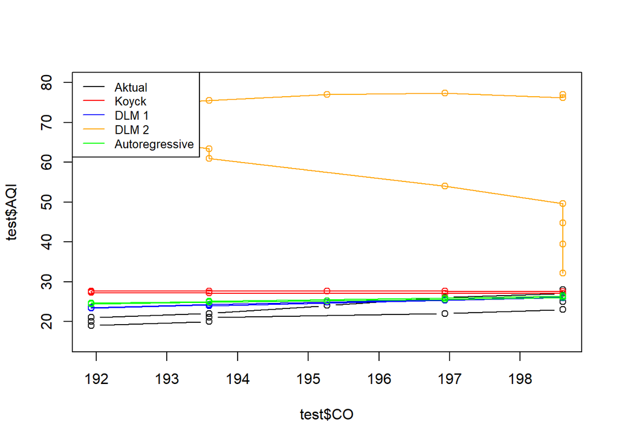

```r
par(mfrow=c(1,1))

plot(test$CO, test$AQI, type="b", col="black", ylim=c(15,80))

points(test$CO, fore.koyck$forecasts, col="red");   lines(test$CO, fore.koyck$forecasts, col="red")
points(test$CO, fore.dlm$forecasts, col="blue");    lines(test$CO, fore.dlm$forecasts, col="blue")
points(test$CO, fore.dlm2$forecasts, col="orange"); lines(test$CO, fore.dlm2$forecasts, col="orange")
points(test$CO, fore.ardl$forecasts, col="green");  lines(test$CO, fore.ardl$forecasts, col="green")

legend("topleft",
       c("Aktual", "Koyck","DLM 1","DLM 2", "Autoregressive"),
       lty=1, col=c("black","red","blue","orange","green"), cex=0.8)
```